# Part 1 - Project Based

**• DOMAIN:** Digital content and entertainment industry

**• CONTEXT:** The objective of this project is to build a text classification model that analyses the customer's sentiments based on their reviews in the IMDB database. The model uses a complex deep learning model to build an embedding layer followed by a classification algorithm to analyse the sentiment of the customers.

**• DATA DESCRIPTION:** The Dataset of 50,000 movie reviews from IMDB, labelled by sentiment (positive/negative). Reviews have been preprocessed, and each review is encoded as a sequence of word indexes (integers). For convenience, the words are indexed by their frequency in the dataset, meaning the for that has index 1 is the most frequent word. Use the first 20 words from each review to speed up training, using a max vocabulary size of 10,000. As a convention, "0" does not stand for a specific word, but instead is used to encode any unknown word.

**• PROJECT OBJECTIVE:** Build a sequential NLP classifier which can use input text parameters to determine the customer sentiments.

**Steps and tasks:**

1. Import and analyse the data set.

   Hint: - Use `imdb.load_data()` method
   - Get train and test set
   - Take 10000 most frequent words

```python
import numpy as np
from keras.preprocessing import sequence
from keras.models import Sequential
from keras.layers import Dense, Embedding, Conv1D, GlobalMaxPool1D, LSTM, TimeDistributed, Flatten
from matplotlib import pyplot
from tensorflow.keras.datasets import imdb
```

```python
(X_train, y_train), (X_test, y_test) = imdb.load_data(num_words=10000, maxlen=300)
print(X_train.shape)
print(X_test.shape)
print(y_train)
print(y_test)
```

```
Downloading data from https://storage.googleapis.com/tensorflow/tf-keras-datasets/imdb.npz
(19051,)
(19450,)
[1 0 0 ... 0 1 0]
[0 1 0 ... 0 0 0]
```

```python
# Summarize number of Labels
print("Labels: ")
print(np.unique(y_train))
```

```
Labels:
[0 1]
```

```python
X_train_max_len = max(len(x) for x in X_train)
print("Max length of sequence in X_train: {}".format(X_train_max_len))

X_test_max_len = max(len(x) for x in X_test)
print("Max length of sequence in X_test:  {}".format(X_test_max_len))
```

```
Max length of sequence in X_train: 299
Max length of sequence in X_test:  299
```

1. Perform relevant sequence adding on the data

```
Review length:
Mean 159.68 words (60.730229)
```

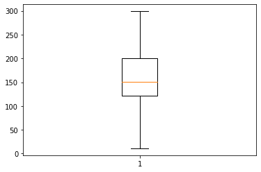

```python
#Padding each sentence to be of same length
# Summarize review length
print("Review length: ")
result = [len(x) for x in X_train]
print("Mean %.2f words (%f)" % (np.mean(result), np.std(result)))
# plot review length
pyplot.boxplot(result)
pyplot.show()

# we can see that max reviews are under the 300 characters mark
```

```python
#padding to 300 length
X_train_padded = sequence.pad_sequences(X_train, maxlen=300)
X_test_padded = sequence.pad_sequences(X_test, maxlen=300)
```

1. Perform following data analysis:

   • Print shape of features and labels

   • Print value of any one feature and it's label

```python
# summarize size
# number of reviews
print("Number of reviews in x_train: {}".format(len(X_train)))
print("Number of reviews in x_test: {}".format(len(X_test)))
#print("Padded Training and Test data: ")
#print(len(X_train.shape))
#print(len(X_test.shape))
```

```
Number of reviews in x_train: 19051
Number of reviews in x_test: 19450
```

```python
# number of words in each review
print("Number of words in each review is {0}".format(X_train_padded[0].shape[0]))
```

```
Number of words in each review is 300
```

```python
y_train.shape
```

```
(19051,)
```

```python
y_test.shape
print("Unique Labels: ")
print(np.unique(y_train))
```

```
Unique Labels:
[0 1]
```

```python
#Print value of any one feature and it's label
print("Value of the 100th review:" ,X_train[100]) #Feature
print("Sentiment Label:", y_train[100]) #Label
```

```
Value of the 100th review: [1, 14, 9, 6, 389, 20, 19, 6, 253, 1096, 65, 5, 4, 6891, 7, 1181, 3855, 5, 4, 620, 756, 7, 803, 674, 11, 113, 97, 14, 6, 55, 467, 2525, 20, 92, 387, 4, 2, 7, 4, 182, 2, 25, 39, 319, 14, 2065, 47, 389, 388, 5, 13, 594, 33, 4, 192, 15, 212, 9, 115, 2525, 88, 156, 40, 2065, 9…
Sentiment Label: 1
```

1. Decode the feature value to get original sentence

```python
#First, retrieve a dictionary that contains mapping of words to their index in the IMDB dataset
imdb_wordindex = imdb.get_word_index()
```

```
Downloading data from https://storage.googleapis.com/tensorflow/tf-keras-datasets/imdb_word_index.json
```

```python
#Now use the dictionary to get the original words from the encodings, for a particular sentence
index_from = 3
imdb_wordindex = {key:value + index_from for key, value in imdb_wordindex.items()}
imdb_wordindex['the']
```

```
4
```

```python
inverted_word = {value: key for key, value in imdb_wordindex.items()}
[inverted_word[index] for index in X_train[100] if index > index_from]
```

```
['this',
 'is',
 'a',
 'wonderful',
 'movie',
 'with',
 'a',
 'fun',
 'clever',
 'story',
 'and',
 'the',
 'dynamics',
 'of',
 'culture',
 'differences',
 'and',
 'the',
 'running',
 'theme',
 'of',
 "what's",
 'important',
 'in',
 'life',
 'make',
 'this',
 'a',
 'very',
 'under',
 'appreciated',
 'movie',
 "don't",
 'let',
 'the',
 'of',
 'the',
 'world',
 'you',
 'from',
```

[output cut: 20 more lines]

```
 'keaton',
 'make',
 'going',
 'from',
 'humor',
 'to',
 'serious',
 'bits',
 'look',
 'tremendously',
 'easy',
 'great',
 'movie',
 'all',
 'around']
```

Get the sentiment for the above sentence

positive (1) negative (0)

```python
y_train[100]
# confirmed that the review is good and the label also confirmed the same
```

```
1
```

1. Design, train, tune and test a sequential model.

Hint: The aim here Is to import the text, process it such a way that it can be taken as an inout to the ML/NN classifiers. Be analytical and experimental here in trying new approaches to design the best model.

```python
#Defining a Sequential Model

vocabulary = 10000
max_words = 300

model = Sequential()
model.add(Embedding(vocabulary, 100, input_length=max_words))
model.add(LSTM(100,return_sequences= True))
dense_layer = Dense(100, activation='relu')
model.add(TimeDistributed(dense_layer))
model.add(Flatten())
model.add(Dense(1, activation='sigmoid'))
```

```python
model.compile(optimizer='adam', loss='binary_crossentropy', metrics='accuracy')
```

```python
print(model.summary())
```

```
Model: "sequential"
_________________________________________________________________
 Layer (type)                Output Shape              Param #
=================================================================
 embedding (Embedding)       (None, 300, 100)          1000000

 lstm (LSTM)                 (None, 300, 100)          80400

 time_distributed (TimeDistr  (None, 300, 100)         10100
 ibuted)

 flatten (Flatten)           (None, 30000)             0

 dense_1 (Dense)             (None, 1)                 30001

=================================================================
Total params: 1,120,501
Trainable params: 1,120,501
Non-trainable params: 0
_________________________________________________________________
None
```

```python
model.fit(X_train_padded, y_train, epochs=5, batch_size=64)
```

```
<keras.callbacks.History at 0x7f93170c92d0>
```

```python
scores, accuracy = model.evaluate(X_test_padded, y_test, verbose=0)
print("Score: {:.4f}".format(scores))
print("Accuracy: {:.4f}".format(accuracy))
```

```
Score: 0.6048
Accuracy: 0.8683
```

```python
#Predict on one sample
goodsample = "i liked the movie"
badsample = "i did not like this movie"
```

```python
from tensorflow.keras.preprocessing.sequence import pad_sequences
for review in [goodsample, badsample]:
    encoded_review = []
    review_split = review.split(" ")
    for word in review_split:
        encoded_review.append(imdb_wordindex[word])
    review_padded = pad_sequences([encoded_review], maxlen=300)
    pred = model.predict(review_padded)
    if pred > 0.5:
        sentiment = 'positive'
    else:
        sentiment = 'negative'
    print("Review: {0}\n\tSentiment: {1}".format(review, sentiment))
```

```
Review: i liked the movie
	Sentiment: positive
Review: i did not like this movie
	Sentiment: negative
```

# Part 2 - Project Based

**• DOMAIN:** Social media analytics

**• CONTEXT:** Past studies in Sarcasm Detection mostly make use of Twitter datasets collected using hashtag based supervision but such datasets are noisy in terms of labels and language. Furthermore, many tweets are replies to other tweets and detecting sarcasm in these requires the availability of contextual tweets.In this hands-on project, the goal is to build a model to detect whether a sentence is sarcastic or not, using Bidirectional LSTMs.

**• DATA DESCRIPTION:** The dataset is collected from two news websites, theonion.com and huffingtonpost.com. This new dataset has the following advantages over the existing Twitter datasets: Since news headlines are written by professionals in a formal manner, there are no spelling mistakes and informal usage. This reduces the sparsity and also increases the chance of finding pre-trained embeddings. Furthermore, since the sole purpose of TheOnion is to publish sarcastic news, we get high-quality labels with much less noise as compared to Twitter datasets. Unlike tweets that reply to other tweets, the news headlines obtained are self-contained. This would help us in teasing apart the real sarcastic elements Content: Each record consists of three attributes: is_sarcastic: 1 if the record is sarcastic otherwise 0 headline: the headline of the news article article_link: link to the original news article. Useful in collecting supplementary data Reference: https://github.com/rishabhmisra/News-Headlines-Dataset-For-Sarcasm-Detection

**• PROJECT OBJECTIVE:** Build a sequential NLP classifier which can use input text parameters to determine the customer sentiments. **Steps and tasks:**

1. Read and explore the data

```python
#Set your project path
project_path =  '/content/drive/MyDrive/Great Learning Projects/NLP Project 2/'
```

```python
import pandas as pd
import os

data = pd.read_json(os.path.join(project_path,'Sarcasm_Headlines_Dataset.json'),lines=True)
```

```python
data
```

|  | article_link | headline | is_sarcastic |
| --- | --- | --- | --- |
| 0 | https://www.huffingtonpost.com/entry/versace-b... | former versace store clerk sues over secret 'b... | 0 |
| 1 | https://www.huffingtonpost.com/entry/roseanne-... | the 'roseanne' revival catches up to our thorn... | 0 |
| 2 | https://local.theonion.com/mom-starting-to-fea... | mom starting to fear son's web series closest ... | 1 |
| 3 | https://politics.theonion.com/boehner-just-wan... | boehner just wants wife to listen, not come up... | 1 |
| 4 | https://www.huffingtonpost.com/entry/jk-rowlin... | j.k. rowling wishes snape happy birthday in th... | 0 |
| ... | ... | ... | ... |
| 26704 | https://www.huffingtonpost.com/entry/american-... | american politics in moral free-fall | 0 |
| 26705 | https://www.huffingtonpost.com/entry/americas-... | america's best 20 hikes | 0 |
| 26706 | https://www.huffingtonpost.com/entry/reparatio... | reparations and obama | 0 |
| 26707 | https://www.huffingtonpost.com/entry/israeli-b... | israeli ban targeting boycott supporters raise... | 0 |
| 26708 | https://www.huffingtonpost.com/entry/gourmet-g... | gourmet gifts for the foodie 2014 | 0 |

26709 rows × 3 columns

```python
print (data.shape)
data.describe(include='all')
```

```
(26709, 3)
```

|  | article_link | headline | is_sarcastic |
| --- | --- | --- | --- |
| count | 26709 | 26709 | 26709.000000 |
| unique | 26708 | 26602 | NaN |
| top | https://www.huffingtonpost.comhttp://nymag.com... | sunday roundup | NaN |
| freq | 2 | 10 | NaN |
| mean | NaN | NaN | 0.438953 |
| std | NaN | NaN | 0.496269 |
| min | NaN | NaN | 0.000000 |
| 25% | NaN | NaN | 0.000000 |
| 50% | NaN | NaN | 0.000000 |
| 75% | NaN | NaN | 1.000000 |
| max | NaN | NaN | 1.000000 |

```python
data['headline'][1]
```

```
"the 'roseanne' revival catches up to our thorny political mood, for better and worse"
```

```python
##The column headline needs to be cleaned up as we have special characters and numbers in the column
import re
from nltk.corpus import stopwords
import nltk
import string
nltk.download('stopwords')
stopwords = set(stopwords.words('english'))
def cleanData(text):
  text = re.sub(r'\d+', '', text)
  text = "".join([char for char in text if char not in string.punctuation])
  return text

data['headline']=data['headline'].apply(cleanData)
```

```python
data['headline'][1]
```

```
'the roseanne revival catches up to our thorny political mood for better and worse'
```

1. Retain relevant columns

```python
#As we only need headline text data and is_sarcastic column for this project. We can drop artical link column here.
data.drop('article_link',inplace=True,axis=1)
```

1. Get length of each sentence

```python
for text in data['headline']: #[:10]
  print(text,"---",len(text))
maxlen = max([len(text) for text in data['headline']])
print("Maximum length for a headline",maxlen)
```

[output not shown]

[output cut: 4946 more lines]

[output not shown]

```python
import numpy as np
import tensorflow as tf
from tensorflow.keras.preprocessing.text import Tokenizer
from tensorflow.keras.preprocessing.sequence import pad_sequences
from tensorflow.keras.layers import Dense, Input, LSTM, Embedding, Dropout, Activation, Flatten, Bidirectional, GlobalMaxPool1D
from tensorflow.keras.models import Model, Sequential
```

1. Define parameters

```python
max_features = 10000
maxlen = max([len(text) for text in data['headline']])
embedding_size = 200
```

1. Get indices for words

```python
tokenizer = Tokenizer(num_words=max_features,filters='!"#$%&()*+,-./:;<=>?@[\\]^_`{|}~\t\n',lower=True,split=' ', char_level=False)
tokenizer.fit_on_texts(data['headline'])
```

1. Create features and labels

```python
X = tokenizer.texts_to_sequences(data['headline'])
X = pad_sequences(X, maxlen = maxlen)
y = np.asarray(data['is_sarcastic'])

print("Number of Samples:", len(X))
print(X[0])
print("Number of Labels: ", len(y))
print(y[0])
```

```
Number of Samples: 26709
[   0    0    0    0    0    0    0    0    0    0    0    0    0    0
    0    0    0    0    0    0    0    0    0    0    0    0    0    0
    0    0    0    0    0    0    0    0    0    0    0    0    0    0
    0    0    0    0    0    0    0    0    0    0    0    0    0    0
    0    0    0    0    0    0    0    0    0    0    0    0    0    0
    0    0    0    0    0    0    0    0    0    0    0    0    0    0
    0    0    0    0    0    0    0    0    0    0    0    0    0    0
    0    0    0    0    0    0    0    0    0    0    0    0    0    0
    0    0    0    0    0    0    0    0    0    0    0    0    0    0
    0    0    0    0    0    0    0    0    0    0    0    0    0    0
    0    0    0    0    0    0    0    0    0    0    0    0    0    0
    0    0    0    0    0    0    0    0    0    0    0    0    0    0
    0    0    0    0    0    0    0    0    0    0    0    0    0    0
    0    0    0    0    0    0    0    0    0    0    0    0    0    0
    0    0    0    0    0    0    0    0    0    0    0    0    0    0
    0    0    0    0    0    0    0    0    0    0    0    0    0    0
    0    0    0    0    0  287  780 3505 2213   47  353   92 2111    5
 2476 8139]
Number of Labels:  26709
0
```

1. Get vocabulary size

```python
num_words=len(tokenizer.word_index)
print (num_words)
```

```
27667
```

```python
glove_file = project_path + "DataSet - glove.6B.50d.txt"
```

```python
EMBEDDING_FILE = glove_file

embeddings = {}
for o in open(EMBEDDING_FILE):
    word = o.split(" ")[0]
    # print(word)
    embd = o.split(" ")[1:]
    embd = np.asarray(embd, dtype='float32')
    # print(embd)
    embeddings[word] = embd
```

```python
import tensorflow as tf

input_layer = Input(shape=(maxlen,),dtype=tf.int64)
embed = Embedding(embedding_matrix.shape[0],output_dim=50,weights=[embedding_matrix],input_length=maxlen, trainable=True)(input_layer)
lstm=Bidirectional(LSTM(128))(embed)
drop=Dropout(0.3)(lstm)
dense =Dense(100,activation='relu')(drop)
out=Dense(2,activation='softmax')(dense)
```

```python
batch_size = 100
epochs = 5

model = Model(input_layer,out)
model.compile(loss='sparse_categorical_crossentropy',optimizer="adam",metrics=['accuracy'])
model.summary()
```

```
Model: "model"
_________________________________________________________________
 Layer (type)                Output Shape              Param #
=================================================================
 input_2 (InputLayer)        [(None, 240)]             0

 embedding_2 (Embedding)     (None, 240, 50)           1383350

 bidirectional (Bidirectiona  (None, 256)              183296
 l)

 dropout (Dropout)           (None, 256)               0

 dense_2 (Dense)             (None, 100)               25700

 dense_3 (Dense)             (None, 2)                 202

=================================================================
Total params: 1,592,548
Trainable params: 1,592,548
Non-trainable params: 0
_________________________________________________________________
```

```python
from sklearn.model_selection import train_test_split
X_train, X_test, y_train, y_test = train_test_split(X, y, test_size=0.2, random_state=10)

model.fit(X_train,y_train,batch_size=batch_size, epochs=epochs, verbose=1)
```

```
<keras.callbacks.History at 0x7f9309b14f90>
```

```python
test_pred = model.predict(np.array(X_test), verbose=1)
```

```python
print(y_test),print(test_pred)
```

```
[1 0 0 ... 1 0 0]
[[1.0727278e-03 9.9892730e-01]
 [9.9778444e-01 2.2156276e-03]
 [9.9976808e-01 2.3197025e-04]
 ...
 [1.7376685e-04 9.9982625e-01]
 [9.8783952e-01 1.2160429e-02]
 [9.9875951e-01 1.2405349e-03]]
```

```
(None, None)
```

```python
test_pred
```

```
array([[1.0727278e-03, 9.9892730e-01],
       [9.9778444e-01, 2.2156276e-03],
       [9.9976808e-01, 2.3197025e-04],
       ...,
       [1.7376685e-04, 9.9982625e-01],
       [9.8783952e-01, 1.2160429e-02],
       [9.9875951e-01, 1.2405349e-03]], dtype=float32)
```

```python
y_test
```

```
array([1, 0, 0, ..., 1, 0, 0])
```

```python
test_pred = [1 if j>i else 0 for i,j in test_pred]
```

```python
from sklearn.metrics import confusion_matrix
confusion_matrix(y_test, test_pred)
```

```
array([[2711,  320],
       [ 378, 1933]])
```

```python
from sklearn.metrics import classification_report

print(classification_report(y_test, test_pred))
```

```
              precision    recall  f1-score   support

           0       0.88      0.89      0.89      3031
           1       0.86      0.84      0.85      2311

    accuracy                           0.87      5342
   macro avg       0.87      0.87      0.87      5342
weighted avg       0.87      0.87      0.87      5342
```